# M2.855_20181_PEC1-Enunciado

[figure not shown]

M2.855 · Modelos avanzados de minería de datos · PEC1

2018-1 · Máster universitario en Ciencia de datos (Data science)

Estudios de Informática, Multimedia y Telecomunicación

# PEC 1: Preparación de datos

A lo largo de esta práctica veremos como aplicar distintas técnicas para la carga y preparación de datos:

1. Carga de conjuntos de datos
2. Análisis de los datos  
   2.1 Análisis estadístico básico  
   2.2 Análisis exploratorio de los datos
3. Reducción de dimensionalidad
4. Aplicación de CART

Para ello vamos a necesitar las siguientes librerías:

```python
from sklearn import datasets
from sklearn.decomposition import PCA
from sklearn.manifold import TSNE
from sklearn.model_selection import train_test_split
from sklearn.tree import DecisionTreeClassifier
from sklearn.metrics import accuracy_score, confusion_matrix
import numpy as np
import matplotlib.pyplot as plt
import matplotlib.mlab as mlab
%matplotlib inline
import pandas as pd
pd.set_option('display.max_columns', None)
```

```python
RANDOM_STATE = 42
TARGET_COL = "target"
```

# 1. Carga del conjunto de datos (1 punto)

En primer lugar, deberéis cargar el conjunto de datos Breast Cancer Wisconsin (más información en https://archive.ics.uci.edu/ml/datasets/Breast+Cancer+Wisconsin+(Diagnostic)). Éste se puede descargar de Internet o puede ser cargado directamente de la librería "scikit-learn", que incorpora un conjunto de datasets muy conocidos y empleados para minería de datos y machine learning (http://scikit-learn.org/stable/datasets/index.html).

**Implementación:** Cargad el conjunto de datos "Breast Cancer Wisconsin" y mostrad el número y nombre de los atributos (variables que podrían ser usadas para predecir la respuesta "Diagnosis"), así como el número de filas obtenidas.

Sugerencia: si usáis sklearn (sklearn.datasets.load_breast_cancer), explorad las diferentes keys del objeto obtenido.

```python
breast_cancer_raw_df = datasets.load_breast_cancer()
```

```python
breast_cancer_raw_df.keys()
```

```
dict_keys(['data', 'target', 'target_names', 'DESCR', 'feature_names'])
```

```python
breast_cancer_features = pd.DataFrame(breast_cancer_raw_df['data'], columns=breast_cancer_raw_df['feature_names'])
breast_cancer_target = pd.DataFrame(breast_cancer_raw_df['target'], columns=[TARGET_COL])
```

```python
print("El numero de atributos/variables aportados es = {}\n".format(len(breast_cancer_features.columns)))
print("Las variables aportadas son = {}\n".format("\' , \'".join(breast_cancer_features.columns.tolist())))
print("El numero de filas/registros aportados es = {}".format(breast_cancer_features.shape[0]))
```

```
El numero de atributos/variables aportados es = 30

Las variables aportadas son = mean radius' , 'mean texture' , 'mean perimeter' , 'mean area' , 'mean smoothness' , 'mean compactness' , 'mean concavity' , 'mean concave points' , 'mean symmetry' , 'mean fractal dimension' , 'radius error' , 'texture error' , 'perimeter error' , 'area error' , 'smoot…

El numero de filas/registros aportados es = 569
```

```python
breast_cancer_df = pd.concat([breast_cancer_target, breast_cancer_features], axis=1)
```

```python
breast_cancer_df.head(5)
```

|  | target | mean radius | mean texture | mean perimeter | mean area | mean smoothness | mean compactness | mean concavity | mean concave points | mean symmetry | mean fractal dimension | radius error | texture error | perimeter error | area error | smoothness error | compactness error | concavity error | concave points error | symmetry error | fractal dimension error | worst radius | worst texture | worst perimeter | worst area | worst smoothness | worst compactness | worst concavity | worst concave points | … |
| --- | --- | --- | --- | --- | --- | --- | --- | --- | --- | --- | --- | --- | --- | --- | --- | --- | --- | --- | --- | --- | --- | --- | --- | --- | --- | --- | --- | --- | --- | --- |
| 0 | 0 | 17.99 | 10.38 | 122.80 | 1001.0 | 0.11840 | 0.27760 | 0.3001 | 0.14710 | 0.2419 | 0.07871 | 1.0950 | 0.9053 | 8.589 | 153.40 | 0.006399 | 0.04904 | 0.05373 | 0.01587 | 0.03003 | 0.006193 | 25.38 | 17.33 | 184.60 | 2019.0 | 0.1622 | 0.6656 | 0.7119 | 0.2654 | … |
| 1 | 0 | 20.57 | 17.77 | 132.90 | 1326.0 | 0.08474 | 0.07864 | 0.0869 | 0.07017 | 0.1812 | 0.05667 | 0.5435 | 0.7339 | 3.398 | 74.08 | 0.005225 | 0.01308 | 0.01860 | 0.01340 | 0.01389 | 0.003532 | 24.99 | 23.41 | 158.80 | 1956.0 | 0.1238 | 0.1866 | 0.2416 | 0.1860 | … |
| 2 | 0 | 19.69 | 21.25 | 130.00 | 1203.0 | 0.10960 | 0.15990 | 0.1974 | 0.12790 | 0.2069 | 0.05999 | 0.7456 | 0.7869 | 4.585 | 94.03 | 0.006150 | 0.04006 | 0.03832 | 0.02058 | 0.02250 | 0.004571 | 23.57 | 25.53 | 152.50 | 1709.0 | 0.1444 | 0.4245 | 0.4504 | 0.2430 | … |
| 3 | 0 | 11.42 | 20.38 | 77.58 | 386.1 | 0.14250 | 0.28390 | 0.2414 | 0.10520 | 0.2597 | 0.09744 | 0.4956 | 1.1560 | 3.445 | 27.23 | 0.009110 | 0.07458 | 0.05661 | 0.01867 | 0.05963 | 0.009208 | 14.91 | 26.50 | 98.87 | 567.7 | 0.2098 | 0.8663 | 0.6869 | 0.2575 | … |
| 4 | 0 | 20.29 | 14.34 | 135.10 | 1297.0 | 0.10030 | 0.13280 | 0.1980 | 0.10430 | 0.1809 | 0.05883 | 0.7572 | 0.7813 | 5.438 | 94.44 | 0.011490 | 0.02461 | 0.05688 | 0.01885 | 0.01756 | 0.005115 | 22.54 | 16.67 | 152.20 | 1575.0 | 0.1374 | 0.2050 | 0.4000 | 0.1625 | … |

# 2. Análisis de los datos

## 2.1 Análisis estadístico básico (1 punto)

**Implementación:** Realizad un análisis estadístico básico indicando, para cada atributo numérico del conjunto de datos, su valor medio y desviación estándard. Para las variables categóricas (en los atributos o la respuesta, si las hay), mostrad la frecuencia con la que aparecen las diferentes clases.

Sugerencia: podeis usar la librería 'pandas' y sus funciones 'describe' y 'value_counts'

```python
breast_cancer_features.describe()
```

|  | mean radius | mean texture | mean perimeter | mean area | mean smoothness | mean compactness | mean concavity | mean concave points | mean symmetry | mean fractal dimension | radius error | texture error | perimeter error | area error | smoothness error | compactness error | concavity error | concave points error | symmetry error | fractal dimension error | worst radius | worst texture | worst perimeter | worst area | worst smoothness | worst compactness | worst concavity | worst concave points | worst symmetry | … |
| --- | --- | --- | --- | --- | --- | --- | --- | --- | --- | --- | --- | --- | --- | --- | --- | --- | --- | --- | --- | --- | --- | --- | --- | --- | --- | --- | --- | --- | --- | --- |
| count | 569.000000 | 569.000000 | 569.000000 | 569.000000 | 569.000000 | 569.000000 | 569.000000 | 569.000000 | 569.000000 | 569.000000 | 569.000000 | 569.000000 | 569.000000 | 569.000000 | 569.000000 | 569.000000 | 569.000000 | 569.000000 | 569.000000 | 569.000000 | 569.000000 | 569.000000 | 569.000000 | 569.000000 | 569.000000 | 569.000000 | 569.000000 | 569.000000 | 569.000000 | … |
| mean | 14.127292 | 19.289649 | 91.969033 | 654.889104 | 0.096360 | 0.104341 | 0.088799 | 0.048919 | 0.181162 | 0.062798 | 0.405172 | 1.216853 | 2.866059 | 40.337079 | 0.007041 | 0.025478 | 0.031894 | 0.011796 | 0.020542 | 0.003795 | 16.269190 | 25.677223 | 107.261213 | 880.583128 | 0.132369 | 0.254265 | 0.272188 | 0.114606 | 0.290076 | … |
| std | 3.524049 | 4.301036 | 24.298981 | 351.914129 | 0.014064 | 0.052813 | 0.079720 | 0.038803 | 0.027414 | 0.007060 | 0.277313 | 0.551648 | 2.021855 | 45.491006 | 0.003003 | 0.017908 | 0.030186 | 0.006170 | 0.008266 | 0.002646 | 4.833242 | 6.146258 | 33.602542 | 569.356993 | 0.022832 | 0.157336 | 0.208624 | 0.065732 | 0.061867 | … |
| min | 6.981000 | 9.710000 | 43.790000 | 143.500000 | 0.052630 | 0.019380 | 0.000000 | 0.000000 | 0.106000 | 0.049960 | 0.111500 | 0.360200 | 0.757000 | 6.802000 | 0.001713 | 0.002252 | 0.000000 | 0.000000 | 0.007882 | 0.000895 | 7.930000 | 12.020000 | 50.410000 | 185.200000 | 0.071170 | 0.027290 | 0.000000 | 0.000000 | 0.156500 | … |
| 25% | 11.700000 | 16.170000 | 75.170000 | 420.300000 | 0.086370 | 0.064920 | 0.029560 | 0.020310 | 0.161900 | 0.057700 | 0.232400 | 0.833900 | 1.606000 | 17.850000 | 0.005169 | 0.013080 | 0.015090 | 0.007638 | 0.015160 | 0.002248 | 13.010000 | 21.080000 | 84.110000 | 515.300000 | 0.116600 | 0.147200 | 0.114500 | 0.064930 | 0.250400 | … |
| 50% | 13.370000 | 18.840000 | 86.240000 | 551.100000 | 0.095870 | 0.092630 | 0.061540 | 0.033500 | 0.179200 | 0.061540 | 0.324200 | 1.108000 | 2.287000 | 24.530000 | 0.006380 | 0.020450 | 0.025890 | 0.010930 | 0.018730 | 0.003187 | 14.970000 | 25.410000 | 97.660000 | 686.500000 | 0.131300 | 0.211900 | 0.226700 | 0.099930 | 0.282200 | … |
| 75% | 15.780000 | 21.800000 | 104.100000 | 782.700000 | 0.105300 | 0.130400 | 0.130700 | 0.074000 | 0.195700 | 0.066120 | 0.478900 | 1.474000 | 3.357000 | 45.190000 | 0.008146 | 0.032450 | 0.042050 | 0.014710 | 0.023480 | 0.004558 | 18.790000 | 29.720000 | 125.400000 | 1084.000000 | 0.146000 | 0.339100 | 0.382900 | 0.161400 | 0.317900 | … |
| max | 28.110000 | 39.280000 | 188.500000 | 2501.000000 | 0.163400 | 0.345400 | 0.426800 | 0.201200 | 0.304000 | 0.097440 | 2.873000 | 4.885000 | 21.980000 | 542.200000 | 0.031130 | 0.135400 | 0.396000 | 0.052790 | 0.078950 | 0.029840 | 36.040000 | 49.540000 | 251.200000 | 4254.000000 | 0.222600 | 1.058000 | 1.252000 | 0.291000 | 0.663800 | … |

```python
pd.value_counts(breast_cancer_target.target.tolist())
```

```
1    357
0    212
dtype: int64
```

**Análisis:** Comentad los resultados.

- En primer lugar vemos que existe una proporcion razonable de 0-1, no pudiendo considerar el modelo desbalanceado. Vemos que en nuestro dataset tenemos mas valores positivos que negativos.
- Haciendo un barrido rapido por las variables del modelo observamos que muchas de ellas no se distribuyen normalmente y que las desviaciones tipicas son altas. Esto sugiere realizar un normalizado de las variables para suavizar el efecto de estos variables atipicos. Seria recomendable plantear incluso su eliminado, como por ejemplo en las variables de area donde el valor maximo esta un casi orden de magnitud por encima de la media.
- En segundo lugar vemos tambien que la escala de las variables, al tratarse de variables de media, cuyas unidades son muy diferentes, es muy diferente, lo cual, refuerza la estrategia del normalizado del dataset.
- Finalmente se trata de un dataset sin valores nulos y con variables continuas, por lo que, no tenemos que plantear tecnicas de imputacion de valores ausentes, ni analizar posibles desbalanceo en conteos de variables categoricas.

## 2.2 Análisis exploratorio de los datos (3 puntos)

En este ejercicio vamos a explorar la relación de algunos de los atributos numéricos con la variable respuesta ("Diagnosis"), tanto gráficamente como cuantitativamente. Para empezar, seleccionad los 4 atributos que queréis explorar. Si habéis usado los nombres de columnas proporcionados por sklearn, una lista de posibles nombres de atributos serían:

```python
feats_to_explore = ['mean radius', 'mean texture', 'mean smoothness', 'mean symmetry']
breast_cancer_features_2explore = breast_cancer_df[feats_to_explore + [TARGET_COL]]
```

**Implementación:** Utilizando una librería gráfica, como por ejemplo "matplotlib", realizad un gráfico del histograma de valores para cada uno de los atributos seleccionados, separados por los valores de clase de la respuesta ("Diagnosis"). La finalidad es observar como se distribuye cada uno de los atributos en función del valor de clase que toman, para poder identificar de forma visual y rápida si algunos atributos permiten diferenciar de forma clara los diferentes diagnósticos de los tumores.

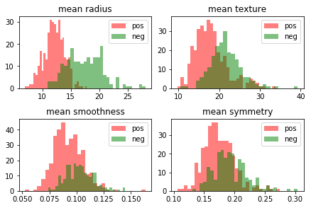

```python
def divide_target(df, col, target_col):
    pos = df[df[target_col] == 1][col]
    neg = df[df[target_col] == 0][col]
    return pos, neg

for num, column in enumerate(feats_to_explore):
    plt.subplot(2, 2, num+1)
    pos, neg = divide_target(breast_cancer_features_2explore[[column, TARGET_COL]], column, TARGET_COL)
    plt.hist(pos, bins=30, alpha=0.5, label='pos', color='r')
    plt.hist(neg, bins=30, alpha=0.5, label='neg', color='g')
    plt.legend(loc='upper right')
    plt.title(column)
    plt.tight_layout(pad=0.4, w_pad=0.5, h_pad=1.0)
```

**Implementación:** Para cada uno de los atributos representados en el ejercicio anterior, mostrad la media y la desviación estándard para cada valor de clase de la respuesta ("Diagnosis"). La finalidad es verificar numéricamente las diferencias identificadas anteriormente de forma visual.

```python
for n, column in enumerate(feats_to_explore):
    print("Para la columna \"{}\" la media y desviacion standard es: \n{}\n".format(
        column, breast_cancer_features_2explore[[TARGET_COL, column]].groupby(TARGET_COL).agg(['mean', 'std'])))
```

```
Para la columna "mean radius" la media y desviacion standard es:
       mean radius
              mean       std
target
0        17.462830  3.203971
1        12.146524  1.780512

Para la columna "mean texture" la media y desviacion standard es:
       mean texture
               mean       std
target
0         21.604906  3.779470
1         17.914762  3.995125

Para la columna "mean smoothness" la media y desviacion standard es:
       mean smoothness
                  mean       std
target
0             0.102898  0.012608
1             0.092478  0.013446

Para la columna "mean symmetry" la media y desviacion standard es:
       mean symmetry
                mean       std
target
0           0.192909  0.027638
1           0.174186  0.024807
```

**Análisis:**  
- Mirando los gráficos, qué atributos te parece que tienen valores claramente diferentes para diagnósticos benignos y malignos? Qué atributos no?  
- Mirando a los valores medios y desviaciones estándard calculadas, te parecen significativas las diferencias para diagnósticos benignos y malignos?  
- BONUS: qué test estadístico podrías usar para comparar las distribuciones de los valores de los atributos cuando los diagnósticos son benignos o malignos? Úsalo para evaluar qué atributos (de entre todos los del conjunto de datos) tienen valores más parecidos en tumores benignos y malignos. Interpreta el resultado.

- De las variables analizadas, la variable *texture* y *radius* parecen contener mas informacion que las otras dos. La diferencia entre las medias es razonablemente alta, especialmente en la variable *radius*. La desviacion tipica de esta variable tambien es informatica siendo muy alta en los negativos.
- Existen diferencias relevantes pero no son suficientemente diferenciables para poder emplear unicamente una variable como indicador del diagnostico. De nuevo *radius* es una variable que puede ser un buen indicador, pero desaconsejaria el empleo de un modelo univariante.
- Vamos a emplear un test de Chi^2.

```python
from sklearn.feature_selection import chi2

for column in feats_to_explore:
    X = np.array(breast_cancer_features_2explore[column])
    y = np.array(breast_cancer_features_2explore[TARGET_COL])
    print("La variable \"{var}\" tiene un p-value en el test de la Ch1^2 de: {val:.5f};".format(var=column, val=chi2(X.reshape(-1, 1), y)[1][0]))
    print("Por tanto, sirve para separar las clases? = {cond}\n".format(cond=float(chi2(X.reshape(-1, 1), y)[1][0])<0.05))
```

```
La variable "mean radius" tiene un p-value en el test de la Ch1^2 de: 0.00000;
Por tanto, sirve para separar las clases? = True

La variable "mean texture" tiene un p-value en el test de la Ch1^2 de: 0.00000;
Por tanto, sirve para separar las clases? = True

La variable "mean smoothness" tiene un p-value en el test de la Ch1^2 de: 0.69863;
Por tanto, sirve para separar las clases? = False

La variable "mean symmetry" tiene un p-value en el test de la Ch1^2 de: 0.61193;
Por tanto, sirve para separar las clases? = False
```

# 3. Reducción de dimensionalidad (2 puntos)

En este ejercicio deberéis aplicar métodos de reducción de dimensionalidad al conjunto original de datos. El objetivo es reducir el conjunto de atributos a un nuevo conjunto con menos dimensiones.

**Implementación:** Aplicad los métodos de reducción de dimensionalidad:  
- Principal Component Analysis (PCA)  
- t-distributed Stochastic Neighbor Embedding (t-SNE)  
para reducir el conjunto de datos a 2 dimensiones.

Sugerencia: No es necesario que programéis los algoritmos, podéis hacer uso de las implementaciones disponibles en la librería "scikit-learn".

```python
# Let's scale the dataset firts
from sklearn.preprocessing import StandardScaler
scaler = StandardScaler()
breast_cancer_features_scaled = scaler.fit_transform(breast_cancer_features)
```

### PCA

```python
pca = PCA(copy=True, tol=0.25, random_state=RANDOM_STATE, n_components=2)
breast_cancer_features_pca = pca.fit_transform(X=breast_cancer_features_scaled, y=breast_cancer_target)
```

### t-SNE

```python
tsne = TSNE(random_state=RANDOM_STATE, n_iter=500, n_components=2)
breast_cancer_features_tsne = tsne.fit_transform(X=breast_cancer_features_scaled, y=breast_cancer_target)
```

**Implementación:** Generad un gráfico (en 2D) con el resultado de cada uno de los métodos de reducción de la dimensión, usando colores diferentes para cada clase de la respuesta, con el objetivo de visualizar si es posible separar eficientemente las clases empleando estos métodos.

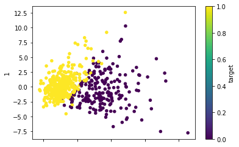

```python
# PCA plot
pd.concat([pd.DataFrame(breast_cancer_features_pca), breast_cancer_target], axis=1).plot.scatter(
    x=0, y=1, c='target', colormap='viridis')
```

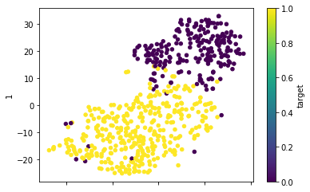

```python
# TSNE plot
pd.concat([pd.DataFrame(breast_cancer_features_tsne), breast_cancer_target], axis=1).plot.scatter(
    x=0, y=1, c='target', colormap='viridis')
```

**Análisis:**  
- Qué método de reducción de dimensionalidad ha resultado más efectivo para visualizar las dos clases de diagnóstico de forma separada?  
- BONUS: cuándo es más apropriado usar PCA o t-SNE?

- Los dos metodos diferencian bastante bien las dos clases. Afinando mucho el comentrio podriamos decir que el metodo PCA genera una division lineal muy buena. En la frontera que provoca existe cierta confusion pero son casos que estan muy cerca los unos de los otros. Sin embargo, la frontera de t-SNE es menos "limpia" teniendo falsos negativos claros.
- Por regla general, en cuando a tecnicas descritivas, t-SNE es mejor cuando el numero de variables es alto, y las relaciones pueden ser no-lineales; siendo mas practico y efectivo PCA cuando las relaciones subyacentes son lineales y se requiere menor tiempo de procesamiento (para datasets grandes tSNE puede tardar mucho tiempo en calcularse). A efectos de empleabilidad, solo PCA se puede emplear como tecnica predictiva (de hecho, hasta el objeto de sklearn de tSNE carece del metodo *transform* necesario para la fase de prediccion de un modelo).

# 4. Aplicación de CART (3 puntos)

En este último ejercicio se trata de aplicar un método de aprendizaje supervisado, concretamente los árboles de decisión, para predecir el diagnóstico de cáncer de mama (tumor benigno o maligno) y evaluar la precisión obtenida con el modelo, usando:

- El conjunto de datos original con todos los atributos
- El conjunto de datos reducido a sólo 2 atributos con el método PCA

**Implementación:** Entrenad dos modelos usando árboles de decisión (con una profundidad máxima limitada a 3 niveles para mantener el modelo simple): uno usando el conjunto de datos original y el otro usando el conjunto de datos reducido con PCA.  
Calculad la precisión de las predicciones obtenidas por cada uno de los modelos (accuracy) así como la matriz de confusión asociada.

Sugerencia: es necesario que generéis un conjunto de datos de entrenamiento para calibrar el modelo, y otro conjunto de test para evaluar la bondad de cada uno de los modelos creados. Podéis usar los módulos 'train_test_split', 'DecisionTreeClassifier' y las funciones dentro del módulo 'metrics' de sckit-learn.

Primera iteracion con todas las variables proporcionadas:

```python
X_train, X_test, y_train, y_test = train_test_split(breast_cancer_features,
                                                    breast_cancer_target,
                                                    test_size=0.33, random_state=RANDOM_STATE)
```

```python
cart1 = DecisionTreeClassifier(max_depth=3).fit(X_train, y_train)
```

```python
cart1 = DecisionTreeClassifier(max_depth=3).fit(X_train, y_train)
y_pred_cart1 = cart1.predict(X_test)
acc1 = accuracy_score(y_pred_cart1, y_test)
cfm1 = confusion_matrix(y_pred_cart1, y_test)
```

```python
print("La precision del primer modelo es: %.3f" % acc1)
print("La matriz de confusion del primer modelo es: \n{}".format(cfm1))
```

[output not shown]

```python
X_train, X_test, y_train, y_test = train_test_split(breast_cancer_features_pca,
                                                    breast_cancer_target,
                                                    test_size=0.33, random_state=RANDOM_STATE)
```

```python
cart2 = DecisionTreeClassifier(max_depth=3).fit(X_train, y_train)
y_pred_cart2 = cart2.predict(X_test)
acc1 = accuracy_score(y_pred_cart2, y_test)
cfm1 = confusion_matrix(y_pred_cart2, y_test)
```

```python
print("La precision del primer modelo es: %.3f" % acc1)
print("La matriz de confusion del primer modelo es: \n{}".format(cfm1))
```

```
La precision del primer modelo es: 0.941
La matriz de confusion del primer modelo es:
[[ 66  10]
 [  1 111]]
```

**Análisis:**  
- Con qué tipo de datos (originales o reducidos) has obtenido una precisión (accuracy) mayor?  
- Si el usuario del modelo de predicción, un hospital por ejemplo, quisese usar el modelo con el menor número de tumores malignos erroneamente clasificados como benignos, cuál de los dos modelos tendría que usar? Porqué?  
- Y si el hospital quisese usar el modelo con el menor número de tumores benignos erroneamente clasificados como malignos, cuál de los dos modelos usaría? Porqué?

- Hemos obtenido un mejor resultado empleando el modelo reducido. Como veiamos en la exploracion de las tecnicas de reduccion de dimensionalidad, PCA generaba una division lineal muy poderosa, con el normalizado. Por tanto, el modelo ha sido capaz de emplear esos dos vectores como variables mas informativas que cuando hemos introducido el dataset completo.
- Como vemos por la matriz de confusion, tenemos un empate en el ratio de falsos positivos, siendo 10 en ambos casos.
- En este caso empleariamos el segundo que tiene un ratio de falsos negativos mas bajo (1/6)